# Assignment_3_2064_Huamani2

# Part 2

## Load Data

```r
set.seed(2064)
mydata = read.csv("Sales_Transactions_Dataset_Weekly.csv")
ts = as.matrix(mydata[, 2:53])
row.names(ts) = mydata[,1]
ts = ts - rowMeans(ts)
```

## Clustering with B

Run k-means algorithm on the coefficient matrix B to cluster the 811 products into 6 clusters. Display time series for products in the same cluster in one figure along with the corresponding cluster center; arrange the 6 figures in 2-by-3 format.

```r
library(splines)
F = ns(1:52, df=9, intercept = FALSE)
F = t (t(F) - colMeans(F))

Bt = solve (t(F) %*% F) %*% t(F) %*% t(ts)
B = t(Bt)

#X:  811 by 52
#B:  811 by 9
#F:  52 by 9
```

### Run kmeans on the coefficient matrix B

```r
myK = 6
mykm1 = kmeans(B,myK, nstart = 20)
```

### Get the cluster centers

```r
mycenters1 = F %*% t(mykm1$centers)
#dim(mycenters1) 52 x 6
```

### Plot the results

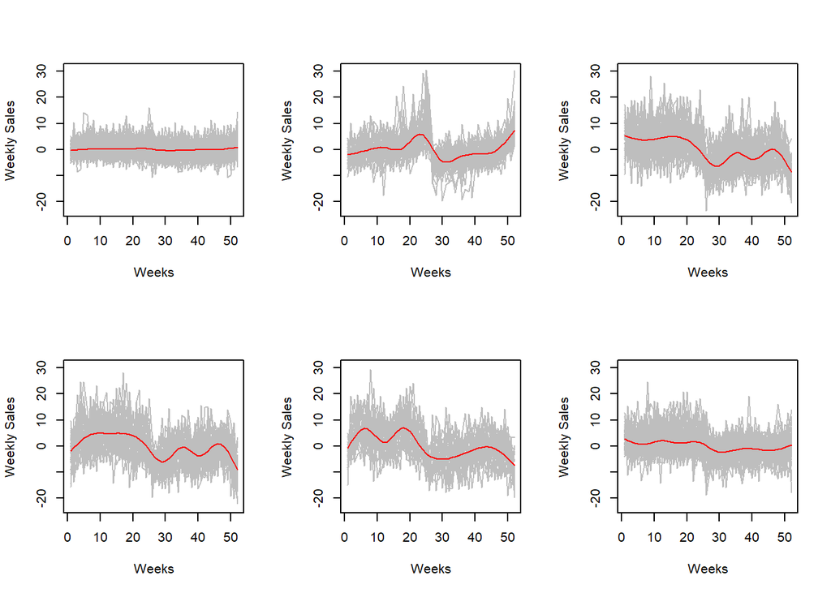

```r
par(mfrow=c(2,3))
for(k in 1:myK){

  id=which(mykm1$cluster==k)

  plot(NA, xlim = c(1, ncol(ts)), ylim = range(ts),
       xlab = "Weeks", ylab = "Weekly Sales")

  for(i in 1:length(id))
    lines(1:ncol(ts), ts[id[i],] , col="gray")

  lines(1:ncol(ts), mycenters1[,k], col="red")
}
```

These resulting plots are smooth.

## Clustering with X

Run k-means algorithm on the original time series matrix X to cluster the 811 products into 6 clusters. Display time series for products in the same cluster in one figure along with the corresponding cluster center; arrange the 6 figures in 2-by-3 format.

### Run k-means on the original matrix X

```r
mykm2 = kmeans(ts,myK, nstart = 20)
```

### Get the cluster centers

```r
mycenters2 = t(mykm2$centers)
#dim(mycenters2) 52 x 6
```

### Plot the results

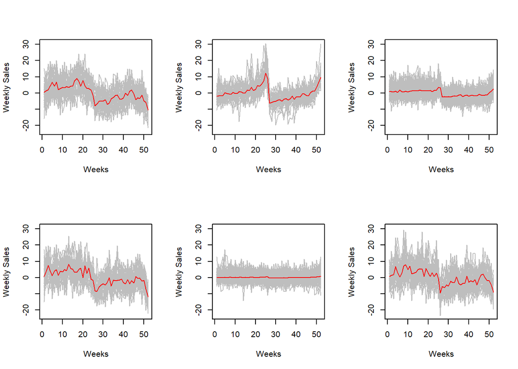

```r
par(mfrow=c(2,3))
for(k in 1:myK){
  id=which(mykm2$cluster==k)
  plot(NA, xlim = c(1, ncol(ts)), ylim = range(ts), xlab = "Weeks", ylab = "Weekly Sales")
  for(i in 1:length(id))
    lines(1:ncol(ts), ts[id[i],] , col="gray")
  lines(1:ncol(ts), mycenters2[,k], col="red")
}
```

When k-means is run on the B-spline basis matrix with natural cubic spline, the plots were smooth. And as expected when k-means is run on the original matrix, the plots are not smooth.